# Project Example

```r
install.packages("ROCR")
```

```r
library(tidyverse)
library(dplyr)
library(caret)
library(ROCR)
```

```r
session=list()
for(i in 1:18){
  session[[i]]=readRDS(paste('session',i,'.rds',sep=''))
}
```

```r
summary(session[[18]])
```

```
               Length Class  Mode
contrast_left   216   -none- numeric
contrast_right  216   -none- numeric
feedback_type   216   -none- numeric
mouse_name        1   -none- character
brain_area     1090   -none- character
date_exp          1   -none- character
spks            216   -none- list
time            216   -none- list
```

```r
# feedback_type
n.session=length(session)

n_success = 0
n_trial = 0
for(i in 1:n.session){
    tmp = session[[i]];
    n_trial = n_trial + length(tmp$feedback_type);
    n_success = n_success + sum(tmp$feedback_type == 1);
}
n_success/n_trial
```

0.710096437709112

Over 70\% trials are success

```r
# brain area
area = c()
for(i in 1:n.session){
    tmp = session[[i]];
    area = c(area, unique(tmp$brain_area))
}

area = unique(area)
length(area)
```

62

There are 62 levels in brain area

### Summary of Features

- `feedback_type`: Numerous instances indicate success, but potential issues may exist.
- `contrast_left` and `contrast_right`: Present in four distinct scenarios. In particular,
  - When left contrast > right contrast, success (1) if turning the wheel to the right and failure (-1) otherwise.
  - When right contrast > left contrast, success (1) if turning the wheel to the left and failure (-1) otherwise.
  - When both left and right contrasts are zero, success (1) if holding the wheel still and failure (-1) otherwise.
  - When left and right contrasts are equal but non-zero, left or right will be randomly chosen (50%) as the correct choice.
- `mouse_name`: Influenced by four factors.
- `date_exp`: May not be directly correlated with success.
- `brain_area`: Comprised of multiple factors; consideration for reduction to a smaller set of factors may be beneficial.
- `spks`: Matrix of dimensions $p_i \times q_i $ across session $i$ for number of trials $N_i$.
- `time`: Vector of dimension $ q$ across sessions for number of trials $N_i$.

## Session 18

- In this section, our focus is solely on session 18.
- Given that there is only one mouse involved, the `mouse_name` feature is omitted.
- The information of `contrast_left` and `contrast_right` are summarized into four factors in `decision` according to the scenrio because a same behavior in different scenrio results in different `feedback_type`
- We employ benchmark method 1, which involves summarizing `brain_area`, `spks`, and `time` into a single number by averaging over `spks`.

```r
n_obs = length(session[[18]]$feedback_type)

dat = tibble(
    feedback_type = as.factor(session[[18]]$feedback_type),
    decision = rep('name', n_obs),
    avg_spikes = rep(0, n_obs)
)

for (i in 1:n_obs){
    # decision
    if (session[[18]]$contrast_left[i] > session[[18]]$contrast_right[i]){
        dat$decision[i] = '1'
    } else if (session[[18]]$contrast_left[i] < session[[18]]$contrast_right[i]){
        dat$decision[i] = '2'
    } else if (session[[18]]$contrast_left[i] == session[[18]]$contrast_right[i]
               & session[[18]]$contrast_left[i] == 0){
        dat$decision[i] = '3'
    } else{
        dat$decision[i] = '4'
    }

    # avg_spks
    spks.trial = session[[18]]$spks[[i]]
    total.spikes = apply(spks.trial, 1, sum)
    dat$avg_spikes[i] = mean(total.spikes)
}

dat$decision = as.factor(dat$decision)
summary(dat)
```

```
 feedback_type decision   avg_spikes
 -1: 42        1:72     Min.   :0.6872
 1 :174        2:71     1st Qu.:1.0055
               3:63     Median :1.1050
               4:10     Mean   :1.0964
                        3rd Qu.:1.2060
                        Max.   :1.5284
```

```r
# Split data into train and test
set.seed(101)
sample <- sample.int(n = n_obs, size = floor(.8 * n_obs), replace = F)
train <- dat[sample, ]
test  <- dat[-sample, ]
```

For simplicity, we fit a logistic regrssion to do the prediction

```r
fit1 <- glm(feedback_type~., data = train, family="binomial")
summary(fit1)
```

```
Call:
glm(formula = feedback_type ~ ., family = "binomial", data = train)

Deviance Residuals:
    Min       1Q   Median       3Q      Max
-2.4607   0.3115   0.4090   0.5674   1.5112

Coefficients:
            Estimate Std. Error z value Pr(>|z|)
(Intercept)  -3.1945     1.5730  -2.031  0.04227 *
decision2    -0.2750     0.6230  -0.441  0.65892
decision3    -0.7646     0.5300  -1.443  0.14915
decision4    -3.1867     0.8569  -3.719  0.00020 ***
avg_spikes    4.9317     1.5257   3.232  0.00123 **
---
Signif. codes:  0 ‘***’ 0.001 ‘**’ 0.01 ‘*’ 0.05 ‘.’ 0.1 ‘ ’ 1

(Dispersion parameter for binomial family taken to be 1)

    Null deviance: 165.27  on 171  degrees of freedom
Residual deviance: 137.34  on 167  degrees of freedom
AIC: 147.34

Number of Fisher Scoring iterations: 5
```

```r
pred1 <- predict(fit1, test %>% select(-feedback_type), type = 'response')
prediction1 <- factor(pred1 > 0.5, labels = c('-1', '1'))
mean(prediction1 != test$feedback_type)
```

0.227272727272727

The prediction error on the test data set is about 22\%.

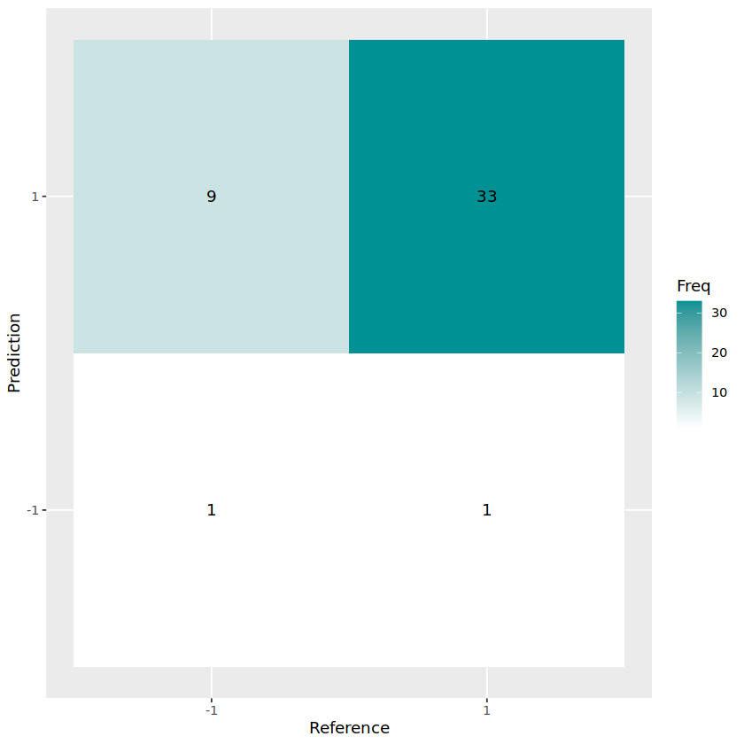

```r
cm <- confusionMatrix(prediction1, test$feedback_type, dnn = c("Prediction", "Reference"))

plt <- as.data.frame(cm$table)

ggplot(plt, aes(Reference, Prediction, fill= Freq)) +
        geom_tile() + geom_text(aes(label=Freq)) +
        scale_fill_gradient(low="white", high="#009194") +
        labs(x = "Reference",y = "Prediction") +
        scale_x_discrete(labels=c("-1","1")) +
        scale_y_discrete(labels=c("-1","1"))
```

However, the prediction is not doing well because if we just bias to success completely, we get same error rate.

```r
prediction0 = factor(rep('1', nrow(test)), levels = c('1', '-1'))
mean(prediction0 != test$feedback_type)
```

0.227272727272727

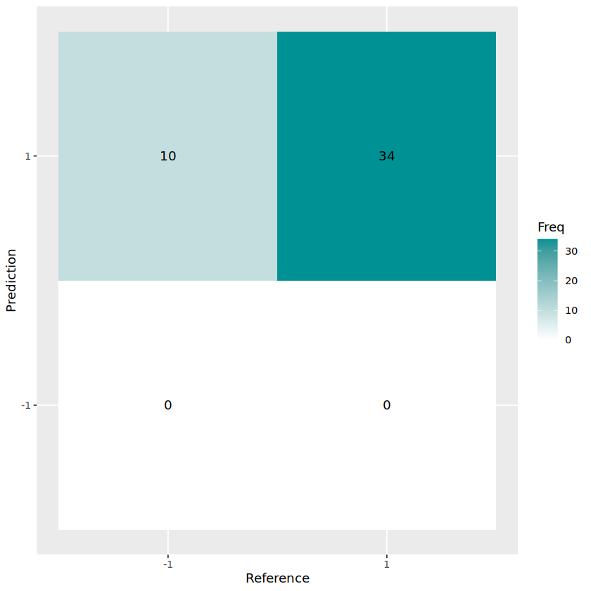

```r
cm <- confusionMatrix(prediction0, test$feedback_type, dnn = c("Prediction", "Reference"))

plt <- as.data.frame(cm$table)

ggplot(plt, aes(Reference, Prediction, fill= Freq)) +
        geom_tile() + geom_text(aes(label=Freq)) +
        scale_fill_gradient(low="white", high="#009194") +
        labs(x = "Reference",y = "Prediction") +
        scale_x_discrete(labels=c("-1","1")) +
        scale_y_discrete(labels=c("-1","1"))
```

An extension to summarize `brain_area`, `spks`, `time` is to average number of spikes per neuron in each brain area (In the project, if you would like to follow this track, an EDA of the average number of spikes per neuron in each brain area is suggested. Same principle applies to the other choice of feature extraction.)

```r
table(session[[18]]$brain_area)
```

```
 ACB  CA3   CP  LGd   OT root   SI  SNr   TH   ZI
 155   35  158   89   26   99   48  130  175  175
```

```r
average_spike_area<-function(i.t,this_session){
  spk.trial = this_session$spks[[i.t]]
  area= this_session$brain_area
  spk.count=apply(spk.trial,1,sum)
  spk.average.tapply=tapply(spk.count, area, mean)
  return(spk.average.tapply)
}
```

```r
n_area = length(unique(session[[18]]$brain_area))
spk_area = matrix(rep(0, n_obs * n_area), n_obs, n_area)
for (i in 1:n_obs){
    spk_area[i,] = average_spike_area(i, session[[18]])
}

spk_area = as_tibble(spk_area)
colnames(spk_area)= unique(session[[18]]$brain_area)
dat1 = bind_cols(dat, spk_area) %>% select(-avg_spikes)
head(dat1)
```

A tibble: 6 × 12

| feedback_type <fct> | decision <fct> | CP <dbl> | ACB <dbl> | OT <dbl> | SI <dbl> | SNr <dbl> | LGd <dbl> | ZI <dbl> | CA3 <dbl> | root <dbl> | TH <dbl> |
| --- | --- | --- | --- | --- | --- | --- | --- | --- | --- | --- | --- |
| 1 | 1 | 1.2709677 | 1.6285714 | 1.1329114 | 0.7865169 | 0.8461538 | 2.080808 | 1.854167 | 0.8000000 | 1.057143 | 1.1257143 |
| 1 | 1 | 1.1612903 | 1.4000000 | 1.1202532 | 1.0449438 | 0.5769231 | 1.858586 | 2.187500 | 1.0615385 | 1.411429 | 1.4114286 |
| -1 | 3 | 0.7225806 | 1.4285714 | 0.9430380 | 1.2471910 | 0.5384615 | 1.919192 | 1.520833 | 0.9230769 | 1.240000 | 1.2285714 |
| -1 | 3 | 0.8903226 | 0.8285714 | 0.6518987 | 1.1573034 | 0.4230769 | 1.646465 | 1.812500 | 0.8153846 | 1.022857 | 1.1828571 |
| 1 | 3 | 0.7290323 | 1.2571429 | 0.5822785 | 0.9887640 | 0.3461538 | 2.363636 | 1.666667 | 0.8846154 | 1.360000 | 1.3771429 |
| 1 | 1 | 0.9806452 | 1.4285714 | 0.8101266 | 0.7191011 | 0.8076923 | 1.939394 | 1.958333 | 0.8230769 | 1.251429 | 0.9314286 |

```r
# Split data into train and test
set.seed(101)
sample <- sample.int(n = n_obs, size = floor(.8 * n_obs), replace = F)
train <- dat1[sample, ]
test  <- dat1[-sample, ]
```

```r
fit2 <- glm(feedback_type~., data = train, family="binomial")
summary(fit2)
```

```
Call:
glm(formula = feedback_type ~ ., family = "binomial", data = train)

Deviance Residuals:
    Min       1Q   Median       3Q      Max
-2.5193   0.1554   0.2999   0.5594   1.9914

Coefficients:
            Estimate Std. Error z value Pr(>|z|)
(Intercept)  -1.8890     2.2237  -0.849 0.395618
decision2    -0.2538     0.7222  -0.351 0.725250
decision3    -1.4426     0.6522  -2.212 0.026982 *
decision4    -3.6987     0.9971  -3.710 0.000208 ***
CP            3.7749     2.5070   1.506 0.132144
ACB          -0.3608     0.6038  -0.598 0.550105
OT            1.8254     2.1131   0.864 0.387668
SI            1.5682     1.0881   1.441 0.149503
SNr          -1.7827     0.9467  -1.883 0.059700 .
LGd           2.2555     1.2566   1.795 0.072671 .
ZI           -2.8712     1.1066  -2.595 0.009473 **
CA3           2.5892     1.3209   1.960 0.049967 *
root          1.5494     1.6697   0.928 0.353443
TH           -3.3211     1.6903  -1.965 0.049441 *
---
Signif. codes:  0 ‘***’ 0.001 ‘**’ 0.01 ‘*’ 0.05 ‘.’ 0.1 ‘ ’ 1

(Dispersion parameter for binomial family taken to be 1)

    Null deviance: 165.27  on 171  degrees of freedom
Residual deviance: 118.94  on 158  degrees of freedom
AIC: 146.94

Number of Fisher Scoring iterations: 6
```

```r
pred2 <- predict(fit2, test %>% select(-feedback_type), type = 'response')
prediction2 <- factor(pred2 > 0.5, labels = c('-1', '1'))
mean(prediction2 != test$feedback_type)
```

0.25

The prediction error on the test data set is about 25%, which is worse than the first model.

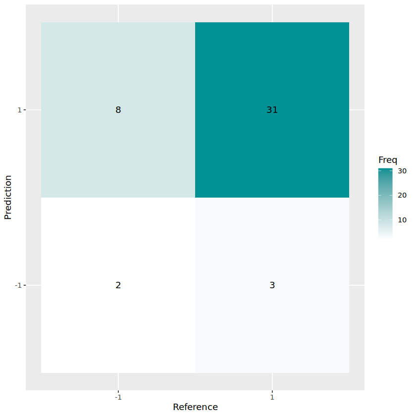

```r
cm <- confusionMatrix(prediction2, test$feedback_type, dnn = c("Prediction", "Reference"))

plt <- as.data.frame(cm$table)

ggplot(plt, aes(Reference, Prediction, fill= Freq)) +
        geom_tile() + geom_text(aes(label=Freq)) +
        scale_fill_gradient(low="white", high="#009194") +
        labs(x = "Reference",y = "Prediction") +
        scale_x_discrete(labels=c("-1","1")) +
        scale_y_discrete(labels=c("-1","1"))
```

It appears that the model predicts more failures compared to the previous one. However, its performance in predicting failures is not particularly strong.

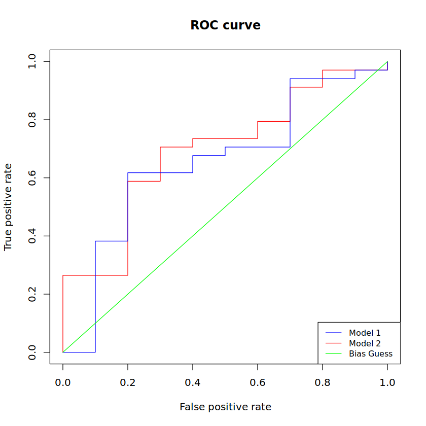

```r
# Model 1
pr = prediction(pred1, test$feedback_type)
prf <- performance(pr, measure = "tpr", x.measure = "fpr")
auc <- performance(pr, measure = "auc")
auc <- auc@y.values[[1]]

# Model 2
pr = prediction(pred2, test$feedback_type)
prf2 <- performance(pr, measure = "tpr", x.measure = "fpr")
auc2 <- performance(pr, measure = "auc")
auc2 <- auc2@y.values[[1]]

# Bias Guess
pred0 = pred1 * 0 + 1
pr = prediction(pred0, test$feedback_type)
prf0 <- performance(pr, measure = "tpr", x.measure = "fpr")
auc0 <- performance(pr, measure = "auc")
auc0 <- auc0@y.values[[1]]

plot(prf2, ,col = 'red', main = 'ROC curve')
plot(prf, add = TRUE, col = 'blue')
plot(prf0, add = TRUE, col = 'green')
legend("bottomright", legend=c("Model 1", "Model 2", "Bias Guess"), col=c("blue", "red", 'green'), lty=1:1,
       cex=0.8)
```

From ROC curve, we see that Mode 1 and Model 2 have similiar performance.

```r
# AUC
print(c(auc, auc2, auc0))
```

```
[1] 0.6558824 0.6941176 0.5000000
```

From AUC, Model 2 is slgithly better than Model 1

## Summary

- Constructing a `decision` variable from `contrast_left` and `contrast_right` has emerged as a significant feature in our preliminary analysis. Modeling different scenarios of success using diverse models may yield better results.
- The method of summarizing `brain_area`, `spks`, and `time` by averaging does not effectively predict feedback type, but there are several potential avenues for improvement.
- Dimension reduction techniques could be applied to these features to enhance predictive performance.
- Techniques such as bootstrapping or weighting the failure group could help maintain label balance of `feedback_type`.
- Incorporating interaction terms in logistic regression or exploring alternative prediction models might also enhance predictive accuracy.
- When comparing predictive models, it would be beneficial to discuss various metrics such as the F1 score, ROC, or AUC. In cases where improving accuracy from the baseline is challenging, credit could be given to models that achieve a better trade-off between false positives and false negatives.
- This note overlooks EDA. In the project, it is essential to conduct EDA to support the selection of feature extraction methods before proceeding to build a predictive model.
- Further exploration and experimentation are warranted to explore additional strategies for improvement.